## 熱門電影大探索！

#### 國企一 B06704090 黃詩恩

#### 電子所 R05943114 吳俊易

#### 國企系 r06724001 黃仕昌

#### 環工所 R06541132 林憲瑋

#### 地理四 b03208045 劉品吟

> 透過抓取臉書上的熱門電影資料，我們發現，熱門電影大致上可以分成兩種型態。

> 一種是名聲和廣告很大的強檔，所以在剛上映時，按讚數、分享數和評論數都在最高，上映之後關注度就開始漸漸往下掉。

> 另一種是比較屬於沒那麼強檔，但隨著越來越多人去看，關注度越來越高，被公認為好看的電影，即使最起初按讚數和分享數還沒那麼多，但是上映一段時間先升後降。

# 1.樂來樂愛你la la land

```r
# lalaland
page1 <- getPage("485682084951730", token = token, n=300, since='2016/09/01', until = '2017/04/30')
```

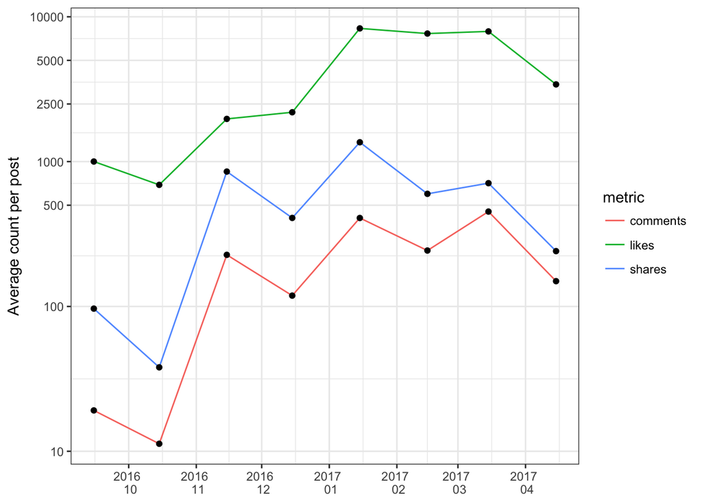

```r
format.facebook.date <- function(datestring) {
  date <- as.POSIXct(datestring, format = "%Y-%m-%dT%H:%M:%S+0000", tz = "GMT")
}
aggregate.metric <- function(metric) {
  m <- aggregate(page1[[paste0(metric, "_count")]], list(month = page1$month),
    mean)
  m$month <- as.Date(paste0(m$month, "-15"))
  m$metric <- metric
  return(m)
}
# create data frame with average metric counts per month
page1$datetime <- format.facebook.date(page1$created_time)
page1$month <- format(page1$datetime, "%Y-%m")
df.list <- lapply(c("likes", "comments", "shares"), aggregate.metric)
df <- do.call(rbind, df.list)

# visualize evolution in metric
## 貼文平均comments, like, share
ggplot(df, aes(x = df$month, y = x, group = metric)) +
  geom_line(aes(color = metric)) +
  scale_x_date(date_breaks = "1 month", date_labels = "%Y \n %m")+
  scale_y_log10("Average count per post",
  breaks = c(0, 10, 100, 500, 1000, 2500, 5000, 10000, 15000))+
  geom_point()+
  theme_bw() +
  theme(axis.title.x = element_blank())
```

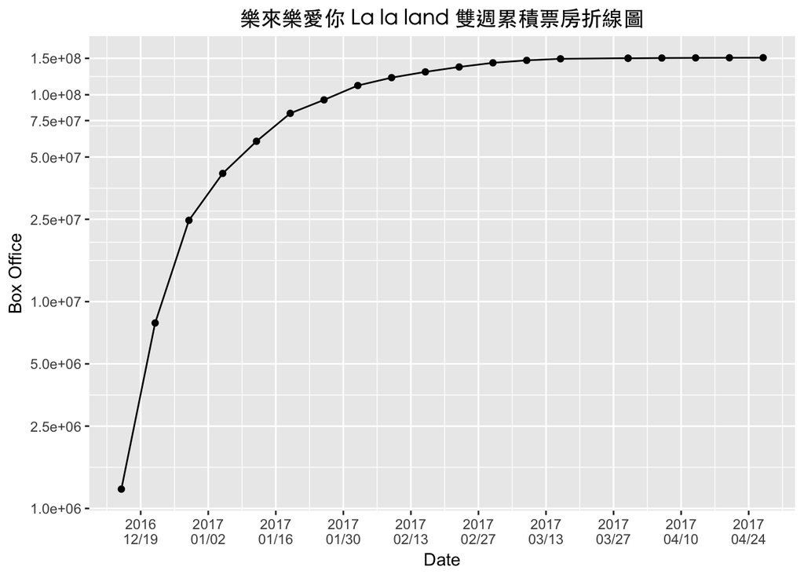

```r
la = read_xlsx("~/Downloads/la la land box.xlsx")
la$Date = as.Date(la$Date)
la$`Box Office`= as.numeric(la$`Box Office`)
ggplot(data = la, aes(Date, `Box Office`))+
  geom_line() +
  scale_x_date(date_breaks = "2 week", date_labels = "%Y\n%m/%d")+
  scale_y_log10(breaks = c(1000000,2500000, 5000000,75000000, 10000000, 25000000, 50000000, 100000000, 150000000))+
  geom_point()+
  ggtitle("樂來樂愛你 La la land 雙週累積票房折線圖")+
  theme(plot.title = element_text(hjust = 0.5, family="黑體-繁 中黑"))
```

# 2.鋼鐵英雄 Hacksaw Ridge

```r
page2 <- getPage("hacksawridge", token = token, n=300, since='2016/11/04', until = '2017/03/09')
```

```r
# aggregate metric counts over month
aggregate.metric2 <- function(metric) {
  m <- aggregate(page2[[paste0(metric, "_count")]], list(month = page2$month),
    mean)
  m$month <- as.Date(paste0(m$month, "-4"))
  m$metric <- metric
  return(m)
}
# create data frame with average metric counts per month
page2$datetime <- format.facebook.date(page2$created_time)
page2$month <- format(page2$datetime, "%Y-%m")
df.list2 <- lapply(c("likes", "comments", "shares"), aggregate.metric2)
df2 <- do.call(rbind, df.list)

#最多like文章類型
like_page <- page2 %>%
              arrange(desc(likes_count))
#like_page <- like_page[,5]
like_page <- select(like_page, one_of(c("type", "likes_count", "datetime")))
head(like_page,10)
```

```
##     type likes_count            datetime
## 1  video       27449 2016-11-10 22:55:45
## 2  video       18876 2016-11-22 19:54:35
## 3  video       15812 2017-02-11 18:00:06
## 4  video       14299 2017-02-24 18:00:40
## 5  photo       12251 2017-02-27 03:42:44
## 6  photo       11782 2017-01-24 19:17:13
## 7  photo       11532 2017-02-01 18:00:03
## 8  video       11488 2017-02-22 18:00:34
## 9  photo       10625 2017-02-27 02:31:56
## 10 photo        9992 2017-02-27 18:00:49
```

[figure not shown]

```r
# visualize evolution in metric
## 貼文平均comments, like, share
ggplot(df2, aes(x = df2$month, y = x, group = metric)) +
  geom_line(aes(color = metric)) +
  scale_x_date(date_breaks = "1 month", date_labels = "%Y \n %m")+
  scale_y_log10("Average count per post",
  breaks = c(0, 10, 100, 500, 1000, 2500, 5000, 10000, 15000))+
  geom_point()+
  theme_bw() +
  theme(axis.title.x = element_blank())
```

```r
##票房折線圖
#box = read_excel("https://github.com/gannasai/R-/blob/master/Hacksaw%20box.xlsx")
box <- read_csv("https://raw.githubusercontent.com/gannasai/R-/master/Hacksaw%20box.csv")
box <- drop_na(box,Date)
Sys.setlocale("LC_TIME", "C")
```

```
## [1] "C"
```

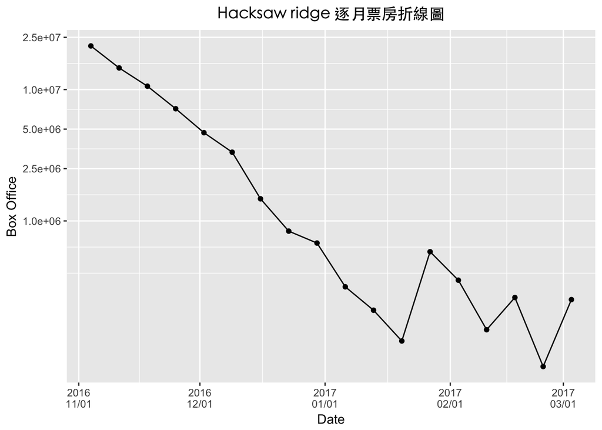

```r
box$Date = as.Date(box$Date, "%Y %b %d")
box$`Box Office`= as.numeric(box$`Box Office`)
ggplot(data = box, aes(Date, `Box Office`))+
  geom_line() +
  scale_x_date(date_breaks = "1 month", date_labels = "%Y\n%m/%d")+
  scale_y_log10(breaks = c(1000000,2500000, 5000000,75000000, 10000000, 25000000, 50000000, 100000000, 150000000))+
  geom_point()+
  ggtitle("Hacksaw ridge 逐月票房折線圖")+
  theme(plot.title = element_text(hjust = 0.5, family="黑體-繁 中黑"))
```

# 3.敦克爾克大行動 DUNKIRK

```r
page.id <-"955813611180538"
page3 <- getPage(page.id, token = token, n=500, since='2016/12/14', until='2017/08/20')
```

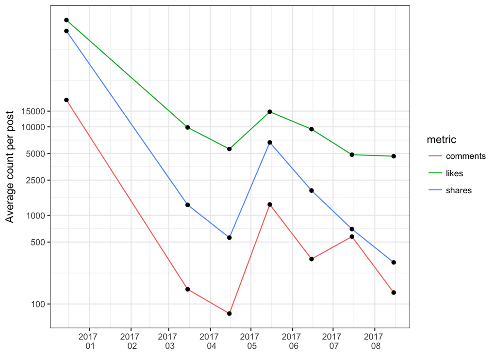

```r
aggregate.metric3 <- function(metric) {
  m <- aggregate(page3[[paste0(metric, "_count")]], list(month = page3$month),
    mean)
  m$month <- as.Date(paste0(m$month, "-15"))
  m$metric <- metric
  return(m)
}

page3$datetime <- format.facebook.date(page3$created_time)
page3$month <- format(page3$datetime, "%Y-%m")

df.list3 <- lapply(c("likes", "comments", "shares"), aggregate.metric3)
df3 <- do.call(rbind, df.list3)

ggplot(df3, aes(x = df3$month, y = x, group = metric)) +
  geom_line(aes(color = metric)) +
  scale_x_date(date_breaks = "1 month", date_labels = "%Y \n %m")+
  scale_y_log10("Average count per post", breaks = c(0, 10, 100, 500, 1000, 2500, 5000, 10000, 15000))+
  geom_point()+
  theme_bw() +
  theme(axis.title.x = element_blank())
```

```r
#box = read_excel("C:/Users/user/Desktop/world_box.xlsx")
#box$Date = as.Date(box$Date)
#box$box_office= as.numeric(box$box_office)

#ggplot(data = box, aes(Date, box_office))+
#  geom_line() +
#  scale_x_date(date_breaks = "2 week", date_labels = "%Y\n%m/%d")+
#  scale_y_log10(breaks = c(2000000,8000000, 100000000,12000000, 20000000, 25000000, 30000000, 35000000, 40000000))+
#  geom_point()+
#  ggtitle("Dunkirk 敦克爾克雙週票房折線圖")+
#  theme(plot.title = element_text(hjust = 0.5))
```

# 4.牠

```r
page4 <- getPage("1623540471295575", token = token, n=300, since='2017/08/01', until = '2017/11/15')
```

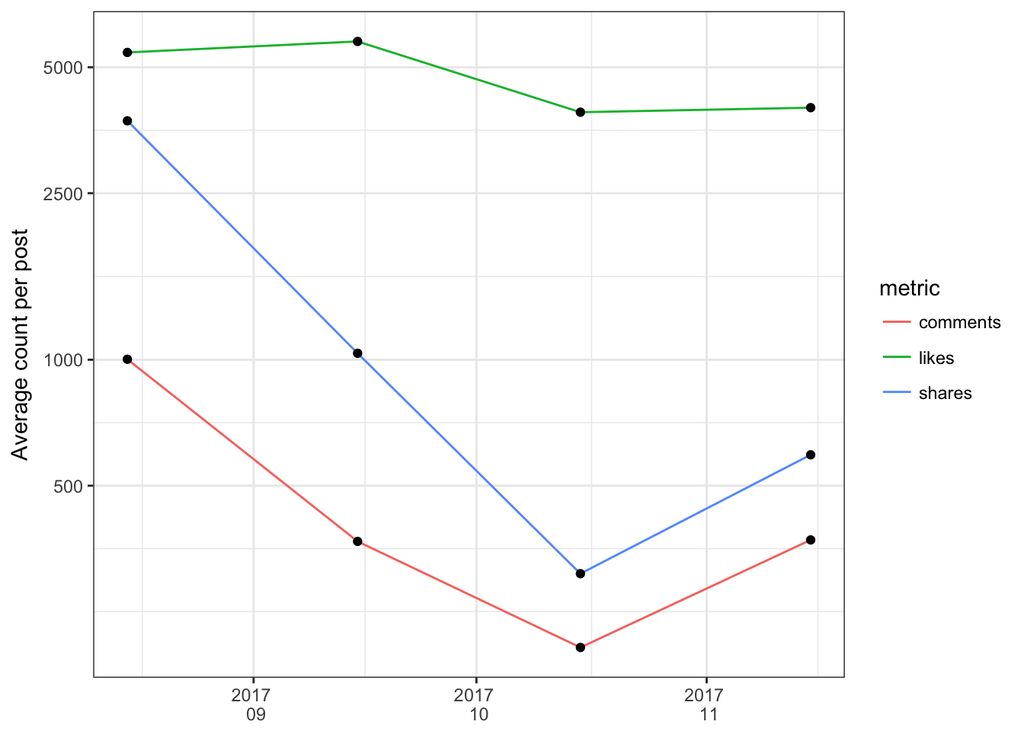

```r
aggregate.metric4 <- function(metric) {
  m <- aggregate(page4[[paste0(metric, "_count")]], list(month = page4$month), mean)
  m$month <- as.Date(paste0(m$month, "-15"))
  m$metric <- metric
  return(m)
  }

page4$datetime <- format.facebook.date(page4$created_time)
page4$month <- format(page4$datetime, "%Y-%m")
df.list4 <- lapply(c("likes", "comments", "shares"), aggregate.metric4)
df4 <- do.call(rbind, df.list4)

ggplot(df4, aes(x = df4$month, y = x, group = metric)) +
  geom_line(aes(color = metric)) +
  scale_x_date(date_breaks = "1 month", date_labels = "%Y \n %m")+
  scale_y_log10("Average count per post", breaks = c(0, 10, 100, 500, 1000, 2500, 5000, 10000, 15000))+
  geom_point()+
  theme_bw() +
  theme(axis.title.x = element_blank())
```